# Project: Data Analysis Of The Movie Database (TMDB)

### Research Question 2: What has been the relationship between movie ratings and the revenue

**Findings:**

1. I cut the data based on movie ratings into 5 different categories (Excellent,Good,Okay,Not Good and Avoid)and then studied the relationship between movie ratings and revenue.
2. 'Excellent Movies' are highly rated and made the most revenue and profit.
3. 'Avoid Movies' ie movies that were the lowest in ratings made the least money

```python
# The number of movies found in these categories
df.groupby('movie_category').count()
```

| movie_category | popularity | budget | revenue | original_title | cast | director | runtime | genres | production_companies | release_date | vote_count | vote_average | release_year | budget_adj | revenue_adj |
| --- | --- | --- | --- | --- | --- | --- | --- | --- | --- | --- | --- | --- | --- | --- | --- |
| Avoid Movies | 1638 | 1638 | 1638 | 1638 | 1638 | 1638 | 1638 | 1638 | 1638 | 1638 | 1638 | 1638 | 1638 | 1638 | 1638 |
| Not Good Movies | 3913 | 3913 | 3913 | 3913 | 3913 | 3913 | 3913 | 3913 | 3913 | 3913 | 3913 | 3913 | 3913 | 3913 | 3913 |
| Okay Movies | 4033 | 4033 | 4033 | 4033 | 4033 | 4033 | 4033 | 4033 | 4033 | 4033 | 4033 | 4033 | 4033 | 4033 | 4033 |
| Good Movies | 1228 | 1228 | 1228 | 1228 | 1228 | 1228 | 1228 | 1228 | 1228 | 1228 | 1228 | 1228 | 1228 | 1228 | 1228 |
| Excellent Movies | 53 | 53 | 53 | 53 | 53 | 53 | 53 | 53 | 53 | 53 | 53 | 53 | 53 | 53 | 53 |

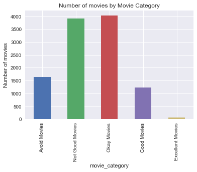

```python
#Bar Distribution of Number of movies by Movie Category

df.groupby('movie_category')['popularity'].count().plot(kind='bar',title='Number of movies by Movie Category');
plt.ylabel('Number of movies')
plt.show()
```

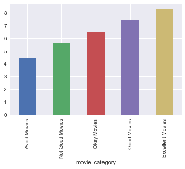

```python
#Average Ratings by movie category
df.groupby('movie_category').vote_average.mean().plot(kind='bar');
```

```python
valid_df.groupby('movie_category')['profit_adj'].mean()
#Excellent movie Mean Profit-397 million
#Good Movies Mean Profit-208 million
```

```
movie_category
Avoid Movies        9.246529e+06
Not Good Movies     5.254419e+07
Okay Movies         1.030076e+08
Good Movies         2.085791e+08
Excellent Movies    3.970101e+08
Name: profit_adj, dtype: float64
```

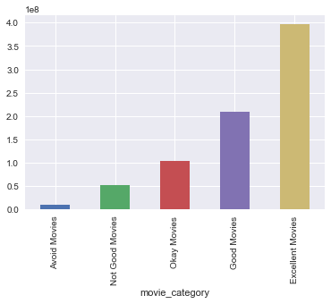

```python
#Average Profit by movie category
valid_df.groupby('movie_category')['profit_adj'].mean().plot(kind='bar');
```

```python
#Average Revenue By movie category
valid_df.groupby('movie_category')['revenue_adj'].mean()
#Excellent movie Mean Revenue-449 million
#Good Movies Mean Revenue-255 million
```

```
movie_category
Avoid Movies        4.477659e+07
Not Good Movies     9.753453e+07
Okay Movies         1.474390e+08
Good Movies         2.552167e+08
Excellent Movies    4.496938e+08
Name: revenue_adj, dtype: float64
```

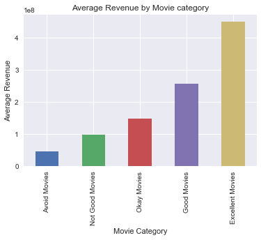

```python
#Average Revenue By movie category
valid_df.groupby('movie_category')['revenue_adj'].mean().plot(kind='bar', title='Average Revenue by Movie category');
plt.xlabel('Movie Category')
plt.ylabel('Average Revenue')
plt.show()
```

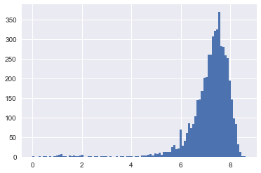

```python
#Budget of the movie distribution has a left skew
np.log10(df[df.budget_adj >0].budget_adj).hist(bins=100);
```

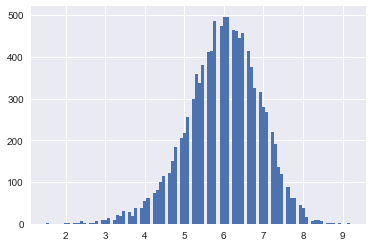

```python
#The movie Ratings look like they are normally distributed
df.vote_average.hist(bins=100);
```

### Research Question 3: Find out the most popular genres by movie ratings

**Findings:**

1. The top rated movies have Documentary and Drama as their most poular genres.
2. Horror is the most popular genre in the low rated movies.
3. Comedy, Thriller and Action are most popular in the mezzanine category.
4. Drama seems to be a very popular genre across all movie category.

```python
#Extract data by movie category
excellent_movies=df.query('movie_category=="Excellent Movies"')
```

```python
#Extract data by movie category
good_movies=df.query('movie_category=="Good Movies"')
```

```python
#Extract data by movie category
okay_movies=df.query('movie_category=="Okay Movies"')
```

```python
#Extract data by movie category
not_good_movies=df.query('movie_category=="Not Good Movies"')
```

```python
#Extract data by movie category
avoid_movies=df.query('movie_category=="Avoid Movies"')
```

```python
#check the length of the data in that category
len(excellent_movies)
```

```
53
```

```python
#check the length of the data in that category
len(good_movies)
```

```
1228
```

```python
#check the length of the data in that category
len(okay_movies)
```

```
4033
```

```python
#check the length of the data in that category
len(not_good_movies)
```

```
3913
```

```python
#check the length of the data in that category
len(avoid_movies)
```

```
1638
```

```python
# write a function to sort the movie genres

def movie_category_genres(data):
    """
        This function takes a Data Frame of movie categories and sorts their genres by the
        number of times they appear in all the movies of that particular movie category
    """

    data_genre_list=[]

    for genre in data['genres']:
        for item in genre:
            data_genre_list.append(item)

    data_genre_set=set(data_genre_list)

    data_genre_tuple=[]
    for genre in data_genre_set:
        data_genre_tuple.append((genre,data_genre_list.count(genre)))

    return sorted(data_genre_tuple, key = lambda t:t[1], reverse=True)
```

```python
#write a function to plot the genres
def bar_plot(data):
    df_data=pd.DataFrame(data,columns=['genre','number of movies'])
    df_data.plot(x='genre',y='number of movies',kind='bar', figsize=(20,6));
    plt.xlabel('Genre')
    plt.ylabel('Number Of Movies')
    plt.title('Number of Movies In A Genre')
    return plt.show()
```

```python
#The most popular genre in the Excellent Movies category was Documentary,
#followed by Drama, Music and Comedy
excellent_movie_genres=movie_category_genres(excellent_movies)
excellent_movie_genres
```

```
[('Documentary', 21),
 ('Drama', 16),
 ('Music', 15),
 ('Comedy', 9),
 ('Crime', 7),
 ('Thriller', 4),
 ('Romance', 3),
 ('Animation', 3),
 ('Action', 2),
 ('', 2),
 ('Horror', 2),
 ('Science Fiction', 2),
 ('Fantasy', 1),
 ('Mystery', 1),
 ('History', 1),
 ('War', 1),
 ('Adventure', 1)]
```

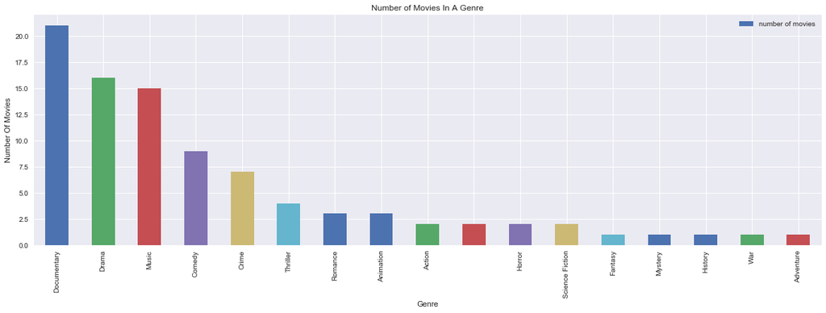

```python
#Excellent Movie Category genre distribution
bar_plot(excellent_movie_genres)
```

```python
#The most popular genre in the Good Movies category was Drama, followed by Comedy, Documentary,
#Action and Thriller
good_movie_genres=movie_category_genres(good_movies)
good_movie_genres
```

```
[('Drama', 623),
 ('Comedy', 296),
 ('Documentary', 215),
 ('Action', 184),
 ('Thriller', 176),
 ('Crime', 153),
 ('Adventure', 149),
 ('Animation', 140),
 ('Romance', 133),
 ('Family', 131),
 ('Science Fiction', 104),
 ('Music', 90),
 ('Fantasy', 89),
 ('Mystery', 64),
 ('History', 60),
 ('War', 47),
 ('Horror', 41),
 ('Foreign', 21),
 ('Western', 21),
 ('TV Movie', 18),
 ('', 4)]
```

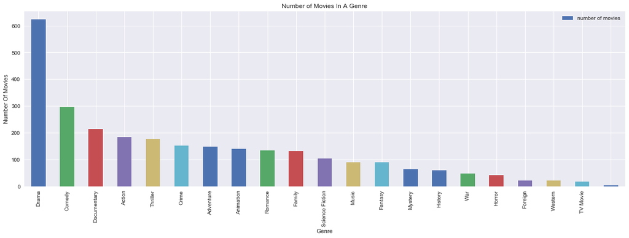

```python
#Good Movie Category genre distribution
bar_plot(good_movie_genres)
```

```python
#The most popular genre in the Okay Movies category was Drama, followed by Comedy,
#Thriller and Action

okay_movie_genres=movie_category_genres(okay_movies)
okay_movie_genres
```

```
[('Drama', 2108),
 ('Comedy', 1387),
 ('Thriller', 954),
 ('Action', 806),
 ('Romance', 752),
 ('Crime', 579),
 ('Adventure', 553),
 ('Family', 477),
 ('Science Fiction', 371),
 ('Horror', 335),
 ('Animation', 332),
 ('Mystery', 320),
 ('Fantasy', 309),
 ('Documentary', 208),
 ('Music', 181),
 ('History', 172),
 ('War', 119),
 ('Foreign', 73),
 ('Western', 70),
 ('TV Movie', 45),
 ('', 9)]
```

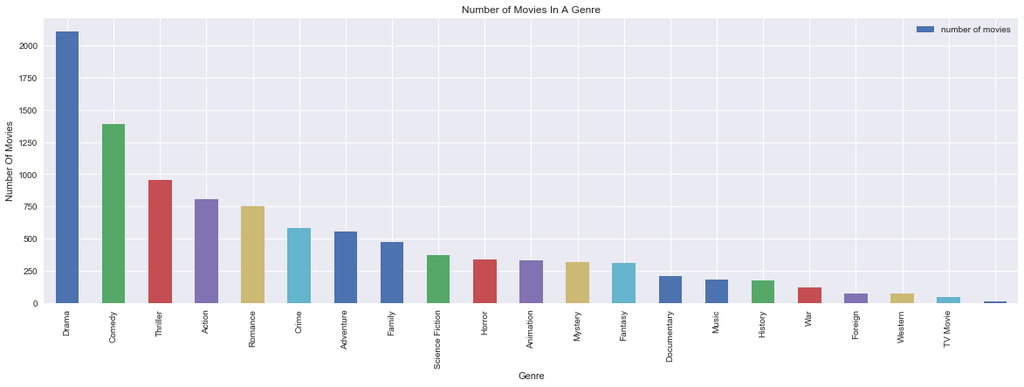

```python
#Okay Movie Category genre distribution
bar_plot(okay_movie_genres)
```

```python
#The most popular genre in the Not Good Movies category was Drama, followed by
#Comedy,Thriller and Action
not_good_movie_genres=movie_category_genres(not_good_movies)
not_good_movie_genres
```

```
[('Drama', 1586),
 ('Comedy', 1580),
 ('Thriller', 1183),
 ('Action', 950),
 ('Horror', 665),
 ('Romance', 658),
 ('Adventure', 543),
 ('Crime', 505),
 ('Family', 471),
 ('Science Fiction', 437),
 ('Fantasy', 361),
 ('Mystery', 316),
 ('Animation', 198),
 ('Music', 106),
 ('History', 91),
 ('War', 84),
 ('TV Movie', 70),
 ('Documentary', 68),
 ('Foreign', 61),
 ('Western', 56),
 ('', 5)]
```

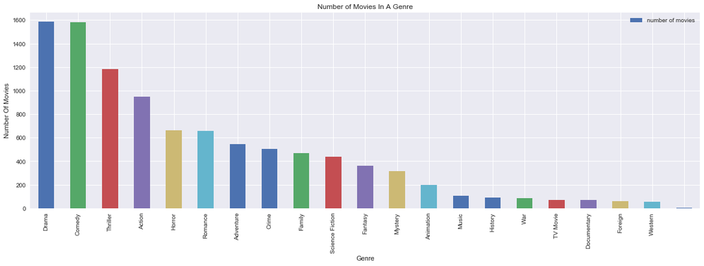

```python
#Not Good Movie Category genre distribution
bar_plot(not_good_movie_genres)
```

```python
#The most popular genre in the Avoid Movies category was Horror, followed by
#Thriller, Comedy, Action and Drama
avoid_movies_genres=movie_category_genres(avoid_movies)
avoid_movies_genres
```

```
[('Horror', 594),
 ('Thriller', 591),
 ('Comedy', 521),
 ('Action', 443),
 ('Drama', 428),
 ('Science Fiction', 316),
 ('Adventure', 225),
 ('Romance', 166),
 ('Fantasy', 156),
 ('Family', 152),
 ('Crime', 111),
 ('Mystery', 109),
 ('TV Movie', 34),
 ('Foreign', 33),
 ('Animation', 26),
 ('War', 19),
 ('Western', 18),
 ('Music', 16),
 ('History', 10),
 ('Documentary', 7),
 ('', 3)]
```

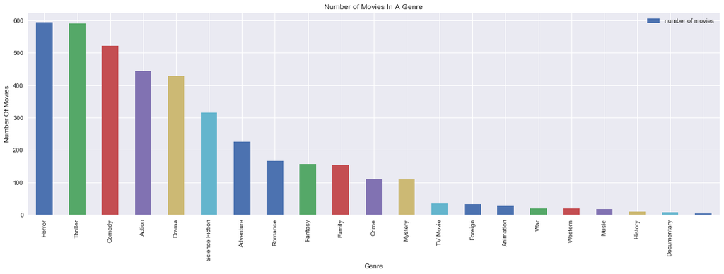

```python
#Avoid Movie Category genre distribution
bar_plot(avoid_movies_genres)
```